# Forecasting_Facebook_FbProphet-Milk Production

##### Forecasting Timeseries Data Using Facebook FbProphet

Steps Required With FbProphet

```python
### pip install pystan
### conda install -c conda-forge fbprophet
import pandas as pd
import fbprophet
import matplotlib.pyplot as plt
%matplotlib inline
```

```python
df=pd.read_csv(r'https://raw.githubusercontent.com/krishnaik06/Feature-Engineering-Live-sessions/master/monthly-milk-production-pounds.csv')
df.head()
```

|  | Month | Monthly milk production: pounds per cow. Jan 62 ? Dec 75 |
| --- | --- | --- |
| 0 | 1962-01 | 589.0 |
| 1 | 1962-02 | 561.0 |
| 2 | 1962-03 | 640.0 |
| 3 | 1962-04 | 656.0 |
| 4 | 1962-05 | 727.0 |

```python
df.tail()
```

|  | Month | Monthly milk production: pounds per cow. Jan 62 ? Dec 75 |
| --- | --- | --- |
| 164 | 1975-09 | 817.0 |
| 165 | 1975-10 | 827.0 |
| 166 | 1975-11 | 797.0 |
| 167 | 1975-12 | 843.0 |
| 168 | Monthly milk production: pounds per cow. Jan 6... | NaN |

```python
df.drop(168,axis=0,inplace=True)
```

```python
df.tail()
```

|  | Month | Monthly milk production: pounds per cow. Jan 62 ? Dec 75 |
| --- | --- | --- |
| 163 | 1975-08 | 858.0 |
| 164 | 1975-09 | 817.0 |
| 165 | 1975-10 | 827.0 |
| 166 | 1975-11 | 797.0 |
| 167 | 1975-12 | 843.0 |

```python
df.columns=["ds","y"]
```

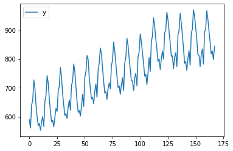

```python
df.plot()
```

```python
df.head()
```

|  | ds | y |
| --- | --- | --- |
| 0 | 1962-01 | 589.0 |
| 1 | 1962-02 | 561.0 |
| 2 | 1962-03 | 640.0 |
| 3 | 1962-04 | 656.0 |
| 4 | 1962-05 | 727.0 |

```python
df['ds']=pd.to_datetime(df['ds'])
```

```python
df.head()
```

|  | ds | y |
| --- | --- | --- |
| 0 | 1962-01-01 | 589.0 |
| 1 | 1962-02-01 | 561.0 |
| 2 | 1962-03-01 | 640.0 |
| 3 | 1962-04-01 | 656.0 |
| 4 | 1962-05-01 | 727.0 |

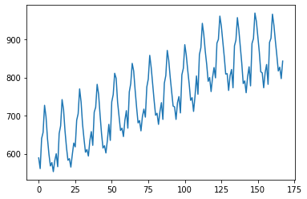

```python
df['y'].plot()
```

```python
df.head()
```

|  | ds | y |
| --- | --- | --- |
| 0 | 1962-01-01 | 589.0 |
| 1 | 1962-02-01 | 561.0 |
| 2 | 1962-03-01 | 640.0 |
| 3 | 1962-04-01 | 656.0 |
| 4 | 1962-05-01 | 727.0 |

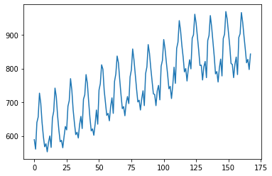

```python
df['y'].plot()
```

```python
df.head()
```

|  | ds | y |
| --- | --- | --- |
| 0 | 1962-01-01 | 589.0 |
| 1 | 1962-02-01 | 561.0 |
| 2 | 1962-03-01 | 640.0 |
| 3 | 1962-04-01 | 656.0 |
| 4 | 1962-05-01 | 727.0 |

```python
from fbprophet import Prophet
```

```python
dir(Prophet)
```

```
['__class__',
 '__delattr__',
 '__dict__',
 '__dir__',
 '__doc__',
 '__eq__',
 '__format__',
 '__ge__',
 '__getattribute__',
 '__gt__',
 '__hash__',
 '__init__',
 '__init_subclass__',
 '__le__',
 '__lt__',
 '__module__',
 '__ne__',
 '__new__',
 '__reduce__',
 '__reduce_ex__',
 '__repr__',
 '__setattr__',
 '__sizeof__',
 '__str__',
 '__subclasshook__',
 '__weakref__',
 '_load_stan_backend',
 'add_country_holidays',
 'add_group_component',
 'add_regressor',
 'add_seasonality',
 'construct_holiday_dataframe',
 'fit',
 'flat_growth_init',
 'flat_trend',
 'fourier_series',
 'initialize_scales',
 'linear_growth_init',
 'logistic_growth_init',
 'make_all_seasonality_features',
```

[output cut: 8 more lines]

```
 'plot_components',
 'predict',
 'predict_seasonal_components',
 'predict_trend',
 'predict_uncertainty',
 'predictive_samples',
 'regressor_column_matrix',
 'sample_model',
 'sample_posterior_predictive',
 'sample_predictive_trend',
 'set_auto_seasonalities',
 'set_changepoints',
 'setup_dataframe',
 'validate_column_name',
 'validate_inputs']
```

```python
df.head()
```

|  | ds | y |
| --- | --- | --- |
| 0 | 1962-01-01 | 589.0 |
| 1 | 1962-02-01 | 561.0 |
| 2 | 1962-03-01 | 640.0 |
| 3 | 1962-04-01 | 656.0 |
| 4 | 1962-05-01 | 727.0 |

```python
### intiialize the Model
model=Prophet(weekly_seasonality=True, daily_seasonality=True).fit(df)
model
```

```
<fbprophet.forecaster.Prophet at 0x7f8e192d0c90>
```

```python
model
```

```
<fbprophet.forecaster.Prophet at 0x7f8e192d0c90>
```

```python
model.seasonalities
```

```
OrderedDict([('yearly',
              {'condition_name': None,
               'fourier_order': 10,
               'mode': 'additive',
               'period': 365.25,
               'prior_scale': 10.0}),
             ('weekly',
              {'condition_name': None,
               'fourier_order': 3,
               'mode': 'additive',
               'period': 7,
               'prior_scale': 10.0}),
             ('daily',
              {'condition_name': None,
               'fourier_order': 4,
               'mode': 'additive',
               'period': 1,
               'prior_scale': 10.0})])
```

```python
model.component_modes
```

```
{'additive': ['yearly',
  'weekly',
  'daily',
  'additive_terms',
  'extra_regressors_additive',
  'holidays'],
 'multiplicative': ['multiplicative_terms', 'extra_regressors_multiplicative']}
```

```python
#### Create future dates of 365 days
future_dates=model.make_future_dataframe(periods=365)
```

```python
df.tail()
```

|  | ds | y |
| --- | --- | --- |
| 163 | 1975-08-01 | 858.0 |
| 164 | 1975-09-01 | 817.0 |
| 165 | 1975-10-01 | 827.0 |
| 166 | 1975-11-01 | 797.0 |
| 167 | 1975-12-01 | 843.0 |

```python
future_dates
```

|  | ds |
| --- | --- |
| 0 | 1962-01-01 |
| 1 | 1962-02-01 |
| 2 | 1962-03-01 |
| 3 | 1962-04-01 |
| 4 | 1962-05-01 |
| ... | ... |
| 528 | 1976-11-26 |
| 529 | 1976-11-27 |
| 530 | 1976-11-28 |
| 531 | 1976-11-29 |
| 532 | 1976-11-30 |

533 rows × 1 columns

```python
### Prediction
prediction=model.predict(future_dates)
```

```python
prediction.head()
```

|  | ds | trend | yhat_lower | yhat_upper | trend_lower | trend_upper | additive_terms | additive_terms_lower | additive_terms_upper | daily | daily_lower | daily_upper | weekly | weekly_lower | weekly_upper | yearly | yearly_lower | yearly_upper | multiplicative_terms | multiplicative_terms_lower | multiplicative_terms_upper | yhat |
| --- | --- | --- | --- | --- | --- | --- | --- | --- | --- | --- | --- | --- | --- | --- | --- | --- | --- | --- | --- | --- | --- | --- |
| 0 | 1962-01-01 | 591.710763 | 578.679221 | 598.174341 | 591.710763 | 591.710763 | -3.566444 | -3.566444 | -3.566444 | 15.267589 | 15.267589 | 15.267589 | 1.518101 | 1.518101 | 1.518101 | -20.352134 | -20.352134 | -20.352134 | 0.0 | 0.0 | 0.0 | 588.144319 |
| 1 | 1962-02-01 | 593.425412 | 537.418966 | 556.012402 | 593.425412 | 593.425412 | -46.722786 | -46.722786 | -46.722786 | 15.267589 | 15.267589 | 15.267589 | 0.979624 | 0.979624 | 0.979624 | -62.969999 | -62.969999 | -62.969999 | 0.0 | 0.0 | 0.0 | 546.702626 |
| 2 | 1962-03-01 | 594.974127 | 632.636496 | 651.592732 | 594.974127 | 594.974127 | 47.519290 | 47.519290 | 47.519290 | 15.267589 | 15.267589 | 15.267589 | 0.979624 | 0.979624 | 0.979624 | 31.272077 | 31.272077 | 31.272077 | 0.0 | 0.0 | 0.0 | 642.493417 |
| 3 | 1962-04-01 | 596.688775 | 647.480129 | 667.763069 | 596.688775 | 596.688775 | 60.427973 | 60.427973 | 60.427973 | 15.267589 | 15.267589 | 15.267589 | -1.312107 | -1.312107 | -1.312107 | 46.472490 | 46.472490 | 46.472490 | 0.0 | 0.0 | 0.0 | 657.116748 |
| 4 | 1962-05-01 | 598.348113 | 712.010951 | 731.637839 | 598.348113 | 598.348113 | 123.195544 | 123.195544 | 123.195544 | 15.267589 | 15.267589 | 15.267589 | -0.035759 | -0.035759 | -0.035759 | 107.963713 | 107.963713 | 107.963713 | 0.0 | 0.0 | 0.0 | 721.543657 |

```python
(8.974783+27.786856)/2
```

```
18.3808195
```

```python
prediction[['ds','yhat','yhat_lower','yhat_upper']].tail()
```

|  | ds | yhat | yhat_lower | yhat_upper |
| --- | --- | --- | --- | --- |
| 528 | 1976-11-26 | 815.688331 | 804.452701 | 827.342394 |
| 529 | 1976-11-27 | 819.139201 | 807.797556 | 829.417431 |
| 530 | 1976-11-28 | 820.923573 | 809.562523 | 832.351429 |
| 531 | 1976-11-29 | 827.239320 | 815.764097 | 837.969428 |
| 532 | 1976-11-30 | 829.292495 | 818.107496 | 839.247692 |

```python
prediction[['ds','yhat','yhat_lower','yhat_upper']].head()
```

|  | ds | yhat | yhat_lower | yhat_upper |
| --- | --- | --- | --- | --- |
| 0 | 1962-01-01 | 588.144319 | 578.679221 | 598.174341 |
| 1 | 1962-02-01 | 546.702626 | 537.418966 | 556.012402 |
| 2 | 1962-03-01 | 642.493417 | 632.636496 | 651.592732 |
| 3 | 1962-04-01 | 657.116748 | 647.480129 | 667.763069 |
| 4 | 1962-05-01 | 721.543657 | 712.010951 | 731.637839 |

#### Plotting the Forecasts

Prophet has an inbuilt feature that enables us to plot the forecasts we just generated. This is achieved using model.plot() and passing in our forecasts as the argument. The blue line in the graph represents the predicted values while the black dots represents the data in our dataset.

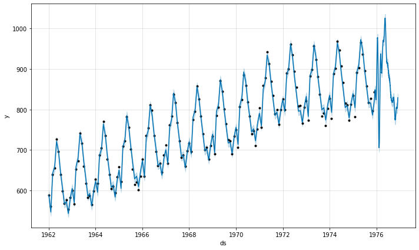

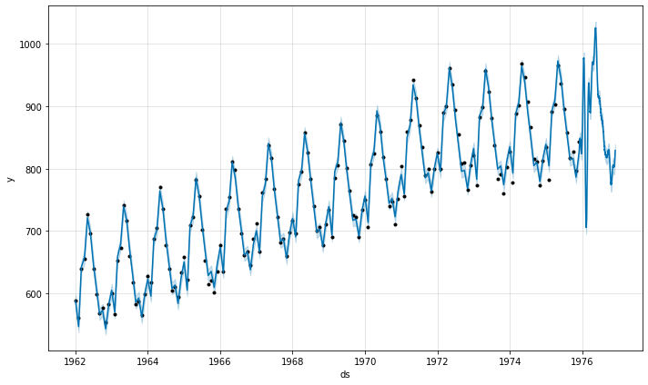

```python
#### plot the predicted projection
model.plot(prediction)
```

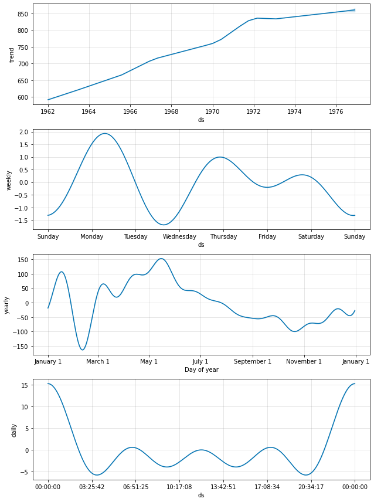

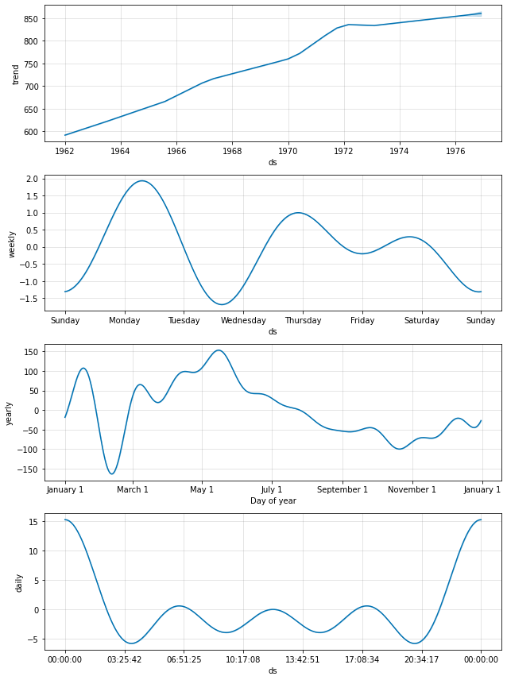

```python
##### Visualize Each Components[Trends,Weekly,Yearly & daily]
model.plot_components(prediction)
```

#### Cross Validation

Next let’s measure the forecast error using the historical data. We’ll do this by comparing the predicted values with the actual values. In order to perform this operation we select cut of points in the history of the data and fit the model with data upto that cut off point. Afterwards we compare the actual values to the predicted values. The cross_validation method allows us to do this in Prophet. This method take the following parameters as explained below:

1. horizon the forecast horizon
2. initial the size of the initial training period
3. period the spacing between cutoff dates

```python
df.shape
```

```
(168, 2)
```

```python
from fbprophet.diagnostics import cross_validation
```

```python
df_cv=cross_validation(model,horizon="365 days",period='180 days',initial='1095 days')
df_cv.head(n=21)
```

```
INFO:fbprophet:Making 21 forecasts with cutoffs between 1965-01-22 00:00:00 and 1974-12-01 00:00:00
```

|  | ds | yhat | yhat_lower | yhat_upper | y | cutoff |
| --- | --- | --- | --- | --- | --- | --- |
| 0 | 1965-02-01 | 628.599891 | 626.651551 | 630.629459 | 622.0 | 1965-01-22 |
| 1 | 1965-03-01 | 718.763502 | 716.416328 | 720.872471 | 709.0 | 1965-01-22 |
| 2 | 1965-04-01 | 733.212783 | 730.315785 | 736.209234 | 722.0 | 1965-01-22 |
| 3 | 1965-05-01 | 804.511440 | 800.645036 | 808.279969 | 782.0 | 1965-01-22 |
| 4 | 1965-06-01 | 761.715864 | 756.361146 | 766.905187 | 756.0 | 1965-01-22 |
| 5 | 1965-07-01 | 710.598980 | 703.597917 | 717.214037 | 702.0 | 1965-01-22 |
| 6 | 1965-08-01 | 666.791566 | 657.938811 | 675.601608 | 653.0 | 1965-01-22 |
| 7 | 1965-09-01 | 635.979022 | 625.722493 | 646.617341 | 615.0 | 1965-01-22 |
| 8 | 1965-10-01 | 635.129678 | 622.364264 | 647.694699 | 621.0 | 1965-01-22 |
| 9 | 1965-11-01 | 629.031742 | 613.501859 | 643.700509 | 602.0 | 1965-01-22 |
| 10 | 1965-12-01 | 662.021070 | 644.681032 | 679.225755 | 635.0 | 1965-01-22 |
| 11 | 1966-01-01 | 691.219686 | 671.117096 | 710.718921 | 677.0 | 1965-01-22 |
| 12 | 1965-08-01 | 657.331670 | 654.358801 | 660.297559 | 653.0 | 1965-07-21 |
| 13 | 1965-09-01 | 626.659906 | 623.526328 | 629.771150 | 615.0 | 1965-07-21 |
| 14 | 1965-10-01 | 621.844538 | 618.660329 | 625.053104 | 621.0 | 1965-07-21 |
| 15 | 1965-11-01 | 615.918327 | 612.076740 | 619.685420 | 602.0 | 1965-07-21 |
| 16 | 1965-12-01 | 649.923623 | 645.945989 | 654.075616 | 635.0 | 1965-07-21 |
| 17 | 1966-01-01 | 672.708975 | 668.084822 | 677.468595 | 677.0 | 1965-07-21 |
| 18 | 1966-02-01 | 637.543542 | 632.508564 | 643.246260 | 635.0 | 1965-07-21 |
| 19 | 1966-03-01 | 720.469147 | 714.363440 | 727.068615 | 736.0 | 1965-07-21 |
| 20 | 1966-04-01 | 729.055634 | 722.473110 | 736.350461 | 755.0 | 1965-07-21 |

```python
df.head()
```

|  | ds | y |
| --- | --- | --- |
| 0 | 1962-01-01 | 589.0 |
| 1 | 1962-02-01 | 561.0 |
| 2 | 1962-03-01 | 640.0 |
| 3 | 1962-04-01 | 656.0 |
| 4 | 1962-05-01 | 727.0 |

```python
df_cv.head()
```

|  | ds | yhat | yhat_lower | yhat_upper | y | cutoff |
| --- | --- | --- | --- | --- | --- | --- |
| 0 | 1965-02-01 | 628.599891 | 626.651551 | 630.629459 | 622.0 | 1965-01-22 |
| 1 | 1965-03-01 | 718.763502 | 716.416328 | 720.872471 | 709.0 | 1965-01-22 |
| 2 | 1965-04-01 | 733.212783 | 730.315785 | 736.209234 | 722.0 | 1965-01-22 |
| 3 | 1965-05-01 | 804.511440 | 800.645036 | 808.279969 | 782.0 | 1965-01-22 |
| 4 | 1965-06-01 | 761.715864 | 756.361146 | 766.905187 | 756.0 | 1965-01-22 |

#### Obtaining the Performance Metrics

We use the performance_metrics utility to compute the Mean Squared Error(MSE), Root Mean Squared Error(RMSE),Mean Absolute Error(MAE), Mean Absolute Percentage Error(MAPE) and the coverage of the the yhat_lower and yhat_upper estimates.

```python
from fbprophet.diagnostics import performance_metrics
df_performance=performance_metrics(df_cv)
df_performance.head(n=21)
```

|  | horizon | mse | rmse | mae | mape | mdape | coverage |
| --- | --- | --- | --- | --- | --- | --- | --- |
| 0 | 38 days | 270.119336 | 16.435308 | 13.001709 | 0.016756 | 0.013771 | 0.20 |
| 1 | 41 days | 267.467546 | 16.354435 | 12.888300 | 0.016645 | 0.013590 | 0.20 |
| 2 | 42 days | 289.503896 | 17.014814 | 13.505455 | 0.017525 | 0.013771 | 0.20 |
| 3 | 43 days | 290.545337 | 17.045390 | 13.665791 | 0.017779 | 0.013771 | 0.20 |
| 4 | 46 days | 274.884250 | 16.579634 | 13.291195 | 0.017268 | 0.013771 | 0.20 |
| 5 | 47 days | 270.462172 | 16.445734 | 13.088034 | 0.017074 | 0.013771 | 0.20 |
| 6 | 48 days | 265.951919 | 16.308032 | 12.805746 | 0.016730 | 0.013590 | 0.24 |
| 7 | 52 days | 357.029458 | 18.895223 | 14.563545 | 0.019018 | 0.013771 | 0.24 |
| 8 | 53 days | 365.962652 | 19.130150 | 15.006485 | 0.019561 | 0.014834 | 0.20 |
| 9 | 54 days | 345.381118 | 18.584432 | 14.331567 | 0.018492 | 0.013771 | 0.20 |
| 10 | 57 days | 315.715537 | 17.768386 | 14.003440 | 0.018125 | 0.013771 | 0.18 |
| 11 | 58 days | 310.913329 | 17.632735 | 14.181497 | 0.018366 | 0.014834 | 0.16 |
| 12 | 59 days | 315.599354 | 17.765116 | 14.416560 | 0.018620 | 0.016441 | 0.16 |
| 13 | 62 days | 334.247997 | 18.282451 | 15.114087 | 0.019525 | 0.018224 | 0.12 |
| 14 | 63 days | 326.633619 | 18.073008 | 14.992925 | 0.019524 | 0.018663 | 0.12 |
| 15 | 64 days | 307.704488 | 17.541508 | 14.235163 | 0.018639 | 0.018224 | 0.16 |
| 16 | 68 days | 306.281193 | 17.500891 | 14.255751 | 0.018644 | 0.016441 | 0.14 |
| 17 | 69 days | 325.523370 | 18.042266 | 14.685602 | 0.019017 | 0.016441 | 0.12 |
| 18 | 72 days | 318.911829 | 17.858103 | 14.204017 | 0.018342 | 0.015530 | 0.16 |
| 19 | 73 days | 319.318424 | 17.869483 | 14.215384 | 0.018349 | 0.015530 | 0.16 |
| 20 | 74 days | 355.551119 | 18.856063 | 15.090478 | 0.019474 | 0.016441 | 0.16 |

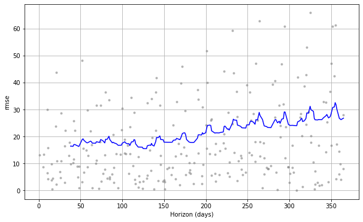

```python
from fbprophet.plot import plot_cross_validation_metric
fig=plot_cross_validation_metric(df_cv,metric='rmse')
```

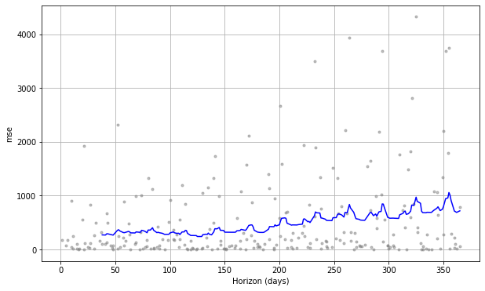

```python
from fbprophet.plot import plot_cross_validation_metric
fig=plot_cross_validation_metric(df_cv,metric='mse')
```

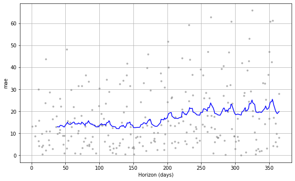

```python
from fbprophet.plot import plot_cross_validation_metric
fig=plot_cross_validation_metric(df_cv,metric='mae')
```

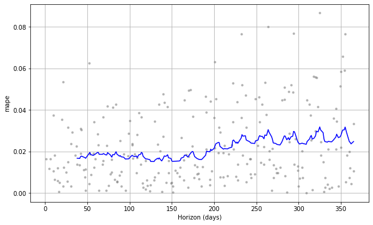

```python
from fbprophet.plot import plot_cross_validation_metric
fig=plot_cross_validation_metric(df_cv,metric='mape')
```

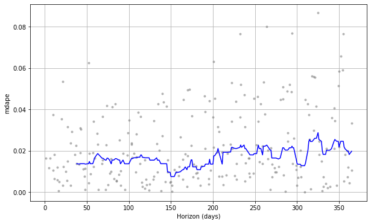

```python
from fbprophet.plot import plot_cross_validation_metric
fig=plot_cross_validation_metric(df_cv,metric='mdape')
```

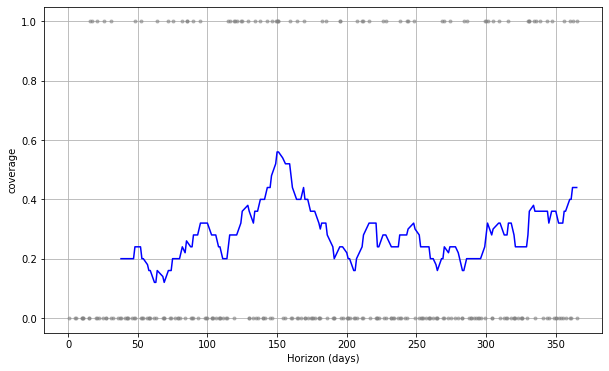

```python
from fbprophet.plot import plot_cross_validation_metric
fig=plot_cross_validation_metric(df_cv,metric='coverage')
```